# Image Processing - Part 2

An image of a texture is given to inspect. Goal of task 1 is finding out out-of-control pixel values considering each row and each column of the matrix. The distribution of the pixels are assumed to be same horizontally and vertically in the examination process. Also, image is turned into grey scale.

# Task 1

# Task 1 - a

At first, the given image is read by R as jpeg and plotted. Also, a new variable imgnew is created to work on in the following steps.

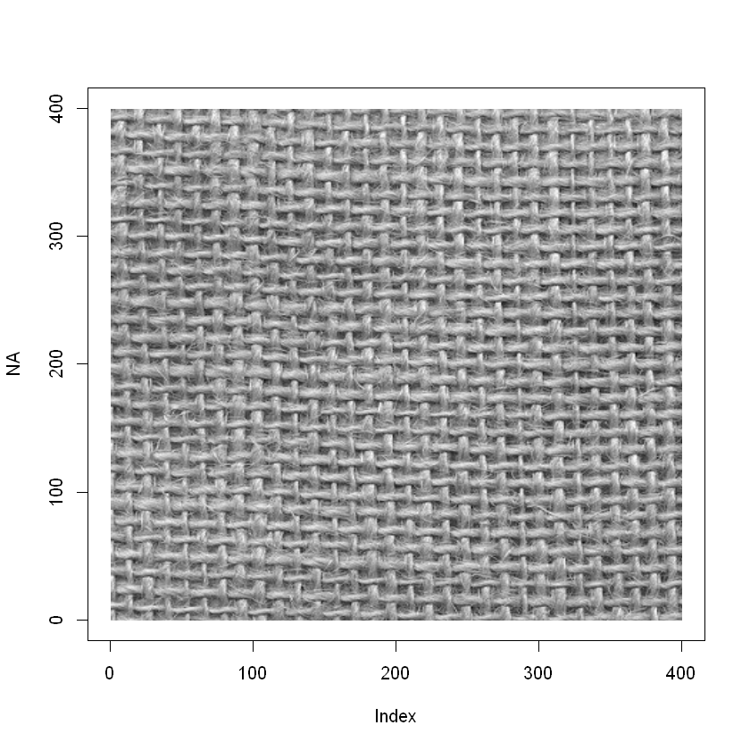

```r
library(jpeg)
img<-readJPEG("C:/Users/Asus/Downloads/group15.jpg")
imgnew = img
plot(NA,xlim=c(0,nrow(img)),ylim=c(0,ncol(img)))
rasterImage(img,0,0,nrow(img),ncol(img))
```

By nrow() function, number of pixel values in a row are found and the outcome value is used to determine the for loop's boundaries. First for loop finds the mean and standard deviation values for each row, and determines upper and lower bounds using these statistics. Second for loop checks the out-of-control pixel values and colors them in black by equating their value to 0.

```r
nrow(img)
for(k in 1:400){
  mean = mean(imgnew[k,,])
  st_dev = sd(imgnew[k,,])
  upper  <-mean+(3*st_dev)
  lower <- mean-(3*st_dev)
  for(t in 1:400){
    if(imgnew[k,t,] < lower || imgnew[k,t,] > upper){
      imgnew[k,t,] = 0
    }
  }
}
```

400

Out-of-control pixel values of last row can be observed on a quality control plot as follows.

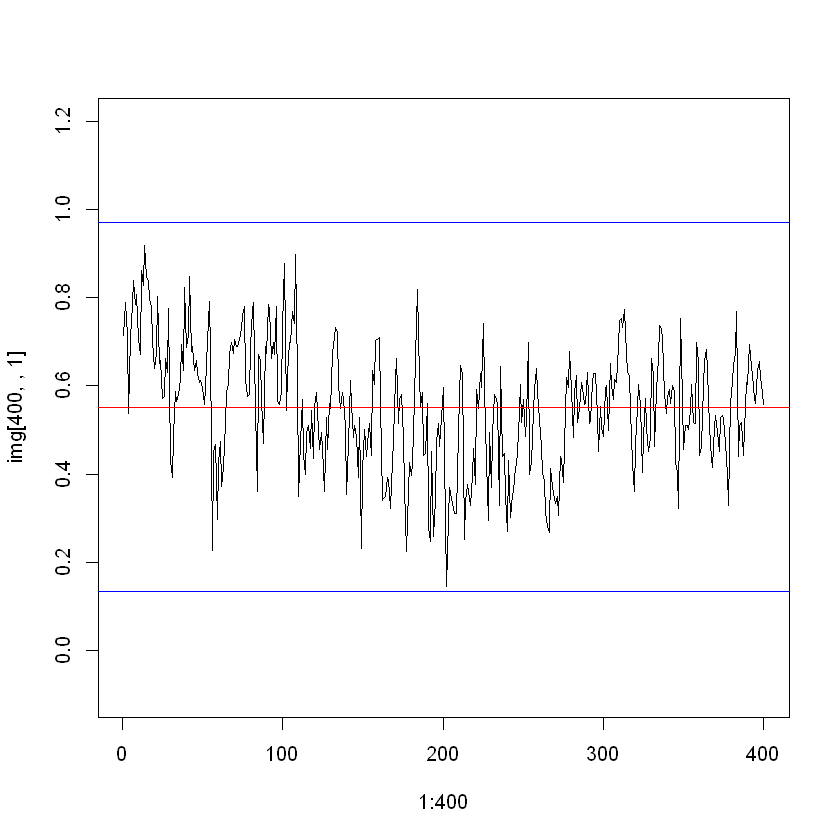

```r
plot(1:400, img[400,,1],ylim=c(-0.1,1.2),type="l")
abline(upper,0, col="blue")
abline(mean,0, col="red")
abline(lower,0, col="blue")
```

In the last row, there weren't any out-of-control values as can be observed from our quality control plot. This makes sense, since the black dots on our new image (imgnew), computed at the following step, are not apparent as well.

New image with replaced pixel values are plotted.

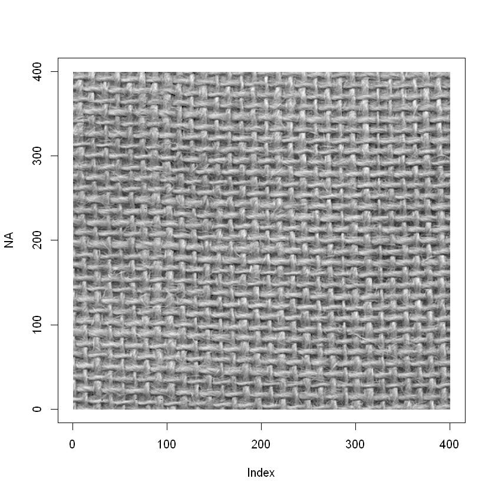

```r
plot(NA,xlim=c(0,nrow(img)),ylim=c(0,ncol(img)))
rasterImage(imgnew,0,0,nrow(imgnew),ncol(imgnew))
```

As can be seen from the photo, the number of black dots is not substantial, this means that most pixel values fall in between the control limits when we consider rows.

# Task 1 - b

In part a, out-of-control values in each row were detected. Now, the same process will be applied for each column.

By ncol() function, number of pixel values in a column are found and the outcome value is used to determine the for loop's boundaries. First for loop finds the mean and standard deviation values for each column, and determines upper and lower bounds using these statistics. Second for loop checks the out-of-control pixel values and colors them in black by equating their value to 0.

```r
ncol(img)
for(k in 1:400){
  mean = mean(imgnew[,k,])
  st_dev = sd(imgnew[,k,])
  upper  <-mean + 3*st_dev
  lower <- mean - 3*st_dev
  for(t in 1:400){
    if(imgnew[t,k,] < lower || imgnew[t,k,] > upper){
      imgnew[t,k,] = 0
    }
  }
}
```

400

Out-of-control pixel values of last column can be observed on a quality control plot as follows.

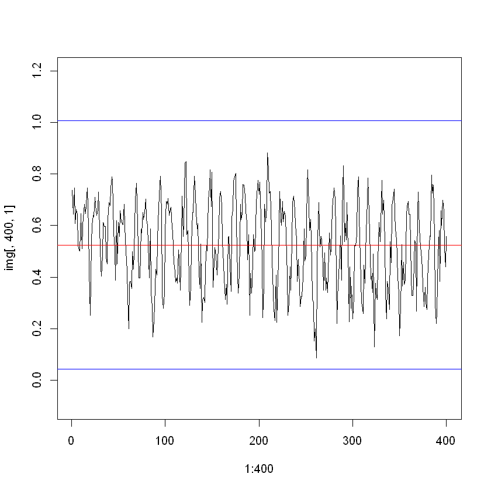

```r
plot(1:400, img[,400,1],ylim=c(-0.1,1.2),type="l")
abline(upper,0, col="blue")
abline(mean,0, col="red")
abline(lower,0, col="blue")
```

In the last column, there weren't any out-of-control values as can be observed from our quality control plot. This makes sense, since the black dots on our new image (imgnew), computed at the following step, are not apparent as well.

New image with replaced pixel values are plotted.

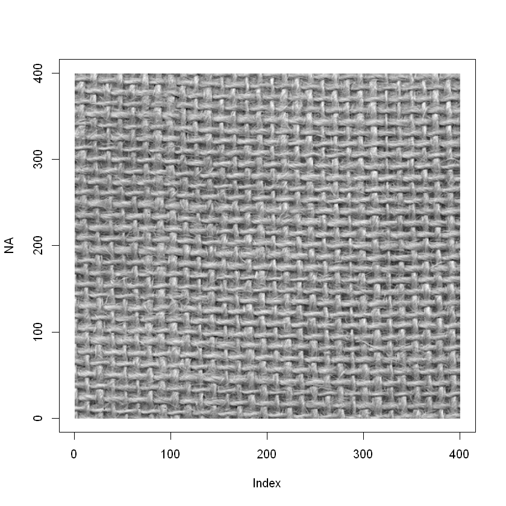

```r
plot(NA,xlim=c(0,nrow(imgnew)),ylim=c(0,ncol(imgnew)))
rasterImage(imgnew,0,0,nrow(imgnew),ncol(imgnew))
```

As can be seen from the photo, the number of black dots is not substantial, this means that most pixel values fall in between the control limits when we consider columns.

# Task 2

Regular control charts were build in Task 1, which assumed that pixel values are independent of each other. However, when working on an image which has a texture, the pixel values are somehow related, which makes the assumption problematic. To avoid from this problem, patches of images are extracted, linear regression models are formed to predict the center pixel using the information of other pixels. Finally, an appropriate chart on the residuals (related with the predicted vs. real center pixel values) is built and out-of-control values are determined.

Image is read and another object called img_c is created in order to track the changes. We worked on only one channel for simplicity, since same steps apply to other two channels.

```
 num [1:400, 1:400] 0.408 0.557 0.706 0.773 0.718 ...
```

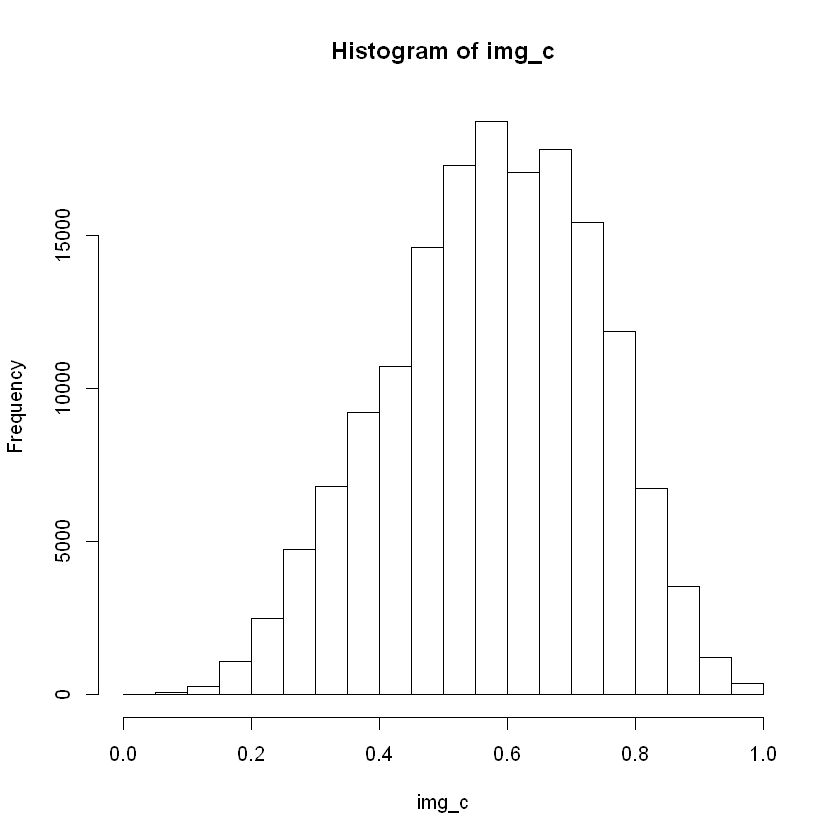

```r
library(jpeg)
img<-readJPEG("C:/Users/Asus/Downloads/group15.jpg")
img_c<-img[,,1]
hist(img_c)
str(img_c)
```

Two objects are created. data_row object is for holding the pixel values of each single patch of size 51*51 as a row of pixel values. big_data object is for holding the pixel values of all patches in a matrix. There are 122,500 patches in total, so each row of big_data matrix holds the pixel values of one patch, and each column in this matrix points out to the same pixel location in a patch i.e 1301st column holds the central pixel values of each patch.

```r
data_row<-matrix(NA,1,2601)
big_data<-matrix(NA,122500,2601)
```

By using for loops, objects formed in the previous step are filled with corresponding pixel values. Upper boundaries of i and j are taken as 350, since half of a window size is 25 from both sides, excluding the center.

```r
for(i in 1:350){
  for(j in 1:350){
    patch<-img_c[i:(i+50),j:(j+50)]
    data_row<-as.vector(t(patch))
    big_data[(i-1)*350+j,1:2601]<-data_row[1:2601]

  }
}
```

In order to form a regression model, values in big_data matrix should be transformed in a data frame. as.data.frame() function does that and colnames() function assigns names for columns of big_data. This will be useful for identifying the column holding the centeral pixel values of each patch.

```r
big_data<-as.data.frame(big_data)
colnames(big_data)
```

3. 'V3'

4. 'V4'

5. 'V5'

6. 'V6'

7. 'V7'

8. 'V8'

9. 'V9'

10. 'V10'

11. 'V11'

12. 'V12'

13. 'V13'

14. 'V14'

15. 'V15'

16. 'V16'

17. 'V17'

18. 'V18'

19. 'V19'

20. 'V20'

21. 'V21'

22. 'V22'

23. 'V23'

24. 'V24'

25. 'V25'

26. 'V26'

27. 'V27'

28. 'V28'

29. 'V29'

30. 'V30'

31. 'V31'

32. 'V32'

33. 'V33'

34. 'V34'

35. 'V35'

36. 'V36'

37. 'V37'

38. 'V38'

39. 'V39'

40. 'V40'

41. 'V41'

42. 'V42'

43. 'V43'

44. 'V44'

45. 'V45'

46. 'V46'

47. 'V47'

48. 'V48'

49. 'V49'

50. 'V50'

51. 'V51'

52. 'V52'

53. 'V53'

54. 'V54'

55. 'V55'

56. 'V56'

57. 'V57'

58. 'V58'

59. 'V59'

60. 'V60'

61. 'V61'

62. 'V62'

63. 'V63'

64. 'V64'

65. 'V65'

66. 'V66'

67. 'V67'

68. 'V68'

69. 'V69'

70. 'V70'

71. 'V71'

72. 'V72'

73. 'V73'

74. 'V74'

75. 'V75'

76. 'V76'

77. 'V77'

78. 'V78'

79. 'V79'

80. 'V80'

81. 'V81'

82. 'V82'

83. 'V83'

84. 'V84'

85. 'V85'

86. 'V86'

87. 'V87'

88. 'V88'

89. 'V89'

90. 'V90'

91. 'V91'

92. 'V92'

93. 'V93'

94. 'V94'

95. 'V95'

96. 'V96'

97. 'V97'

98. 'V98'

99. 'V99'

100. 'V100'

101. 'V101'

102. 'V102'

103. 'V103'

104. 'V104'

105. 'V105'

106. 'V106'

107. 'V107'

108. 'V108'

109. 'V109'

110. 'V110'

111. 'V111'

112. 'V112'

113. 'V113'

114. 'V114'

115. 'V115'

116. 'V116'

117. 'V117'

118. 'V118'

119. 'V119'

120. 'V120'

121. 'V121'

122. 'V122'

123. 'V123'

124. 'V124'

125. 'V125'

126. 'V126'

127. 'V127'

128. 'V128'

129. 'V129'

130. 'V130'

131. 'V131'

132. 'V132'

133. 'V133'

134. 'V134'

135. 'V135'

136. 'V136'

137. 'V137'

138. 'V138'

139. 'V139'

140. 'V140'

141. 'V141'

142. 'V142'

143. 'V143'

144. 'V144'

145. 'V145'

146. 'V146'

147. 'V147'

148. 'V148'

149. 'V149'

150. 'V150'

151. 'V151'

152. 'V152'

153. 'V153'

154. 'V154'

155. 'V155'

156. 'V156'

157. 'V157'

158. 'V158'

159. 'V159'

160. 'V160'

161. 'V161'

162. 'V162'

163. 'V163'

164. 'V164'

165. 'V165'

166. 'V166'

167. 'V167'

168. 'V168'

169. 'V169'

170. 'V170'

171. 'V171'

172. 'V172'

173. 'V173'

174. 'V174'

175. 'V175'

176. 'V176'

177. 'V177'

178. 'V178'

179. 'V179'

180. 'V180'

181. 'V181'

182. 'V182'

183. 'V183'

184. 'V184'

185. 'V185'

186. 'V186'

187. 'V187'

188. 'V188'

189. 'V189'

190. 'V190'

191. 'V191'

192. 'V192'

193. 'V193'

194. 'V194'

195. 'V195'

196. 'V196'

197. 'V197'

198. 'V198'

199. 'V199'

200. 'V200'

201. 'V201'

202. 'V202'

203. 'V203'

204. 'V204'

205. 'V205'

206. 'V206'

207. 'V207'

208. 'V208'

209. 'V209'

210. 'V210'

211. 'V211'

212. 'V212'

213. 'V213'

214. 'V214'

215. 'V215'

216. 'V216'

217. 'V217'

218. 'V218'

219. 'V219'

220. 'V220'

221. 'V221'

222. 'V222'

223. 'V223'

224. 'V224'

225. 'V225'

226. 'V226'

227. 'V227'

228. 'V228'

229. 'V229'

230. 'V230'

231. 'V231'

232. 'V232'

233. 'V233'

234. 'V234'

235. 'V235'

236. 'V236'

237. 'V237'

238. 'V238'

239. 'V239'

240. 'V240'

241. 'V241'

242. 'V242'

243. 'V243'

244. 'V244'

245. 'V245'

246. 'V246'

247. 'V247'

248. 'V248'

249. 'V249'

250. 'V250'

251. 'V251'

252. 'V252'

253. 'V253'

254. 'V254'

255. 'V255'

256. 'V256'

257. 'V257'

258. 'V258'

259. 'V259'

260. 'V260'

261. 'V261'

262. 'V262'

263. 'V263'

264. 'V264'

265. 'V265'

266. 'V266'

267. 'V267'

268. 'V268'

269. 'V269'

270. 'V270'

271. 'V271'

272. 'V272'

273. 'V273'

274. 'V274'

275. 'V275'

276. 'V276'

277. 'V277'

278. 'V278'

279. 'V279'

280. 'V280'

281. 'V281'

282. 'V282'

283. 'V283'

284. 'V284'

285. 'V285'

286. 'V286'

287. 'V287'

288. 'V288'

289. 'V289'

290. 'V290'

291. 'V291'

292. 'V292'

293. 'V293'

294. 'V294'

295. 'V295'

296. 'V296'

297. 'V297'

298. 'V298'

299. 'V299'

300. 'V300'

301. 'V301'

302. 'V302'

303. 'V303'

304. 'V304'

305. 'V305'

306. 'V306'

307. 'V307'

308. 'V308'

309. 'V309'

310. 'V310'

311. 'V311'

312. 'V312'

313. 'V313'

314. 'V314'

315. 'V315'

316. 'V316'

317. 'V317'

318. 'V318'

319. 'V319'

320. 'V320'

321. 'V321'

322. 'V322'

323. 'V323'

324. 'V324'

325. 'V325'

326. 'V326'

327. 'V327'

328. 'V328'

329. 'V329'

330. 'V330'

331. 'V331'

332. 'V332'

333. 'V333'

334. 'V334'

335. 'V335'

336. 'V336'

337. 'V337'

338. 'V338'

339. 'V339'

340. 'V340'

341. 'V341'

342. 'V342'

343. 'V343'

344. 'V344'

345. 'V345'

346. 'V346'

347. 'V347'

348. 'V348'

349. 'V349'

350. 'V350'

351. 'V351'

352. 'V352'

353. 'V353'

354. 'V354'

355. 'V355'

356. 'V356'

357. 'V357'

358. 'V358'

359. 'V359'

360. 'V360'

361. 'V361'

362. 'V362'

363. 'V363'

364. 'V364'

365. 'V365'

366. 'V366'

367. 'V367'

368. 'V368'

369. 'V369'

370. 'V370'

371. 'V371'

372. 'V372'

373. 'V373'

374. 'V374'

375. 'V375'

376. 'V376'

377. 'V377'

378. 'V378'

379. 'V379'

380. 'V380'

381. 'V381'

382. 'V382'

383. 'V383'

384. 'V384'

385. 'V385'

386. 'V386'

387. 'V387'

388. 'V388'

389. 'V389'

390. 'V390'

391. 'V391'

392. 'V392'

393. 'V393'

394. 'V394'

395. 'V395'

396. 'V396'

397. 'V397'

398. 'V398'

399. 'V399'

400. 'V400'

401. 'V401'

402. 'V402'

403. 'V403'

404. 'V404'

405. 'V405'

406. 'V406'

407. 'V407'

408. 'V408'

409. 'V409'

410. 'V410'

411. 'V411'

412. 'V412'

413. 'V413'

414. 'V414'

415. 'V415'

416. 'V416'

417. 'V417'

418. 'V418'

419. 'V419'

420. 'V420'

421. 'V421'

422. 'V422'

423. 'V423'

424. 'V424'

425. 'V425'

426. 'V426'

427. 'V427'

428. 'V428'

429. 'V429'

430. 'V430'

431. 'V431'

432. 'V432'

433. 'V433'

434. 'V434'

435. 'V435'

436. 'V436'

437. 'V437'

438. 'V438'

439. 'V439'

440. 'V440'

441. 'V441'

442. 'V442'

443. 'V443'

444. 'V444'

445. 'V445'

446. 'V446'

447. 'V447'

448. 'V448'

449. 'V449'

450. 'V450'

451. 'V451'

452. 'V452'

453. 'V453'

454. 'V454'

455. 'V455'

456. 'V456'

457. 'V457'

458. 'V458'

459. 'V459'

460. 'V460'

461. 'V461'

462. 'V462'

463. 'V463'

464. 'V464'

465. 'V465'

466. 'V466'

467. 'V467'

468. 'V468'

469. 'V469'

470. 'V470'

471. 'V471'

472. 'V472'

473. 'V473'

474. 'V474'

475. 'V475'

476. 'V476'

477. 'V477'

478. 'V478'

479. 'V479'

480. 'V480'

481. 'V481'

482. 'V482'

483. 'V483'

484. 'V484'

485. 'V485'

486. 'V486'

487. 'V487'

488. 'V488'

489. 'V489'

490. 'V490'

491. 'V491'

492. 'V492'

493. 'V493'

494. 'V494'

495. 'V495'

496. 'V496'

497. 'V497'

498. 'V498'

499. 'V499'

500. 'V500'

501. 'V501'

502. 'V502'

503. 'V503'

504. 'V504'

505. 'V505'

506. 'V506'

507. 'V507'

508. 'V508'

509. 'V509'

510. 'V510'

511. 'V511'

512. 'V512'

513. 'V513'

514. 'V514'

515. 'V515'

516. 'V516'

517. 'V517'

518. 'V518'

519. 'V519'

520. 'V520'

521. 'V521'

522. 'V522'

523. 'V523'

524. 'V524'

525. 'V525'

526. 'V526'

527. 'V527'

528. 'V528'

529. 'V529'

530. 'V530'

531. 'V531'

532. 'V532'

533. 'V533'

534. 'V534'

535. 'V535'

536. 'V536'

537. 'V537'

538. 'V538'

539. 'V539'

540. 'V540'

541. 'V541'

542. 'V542'

543. 'V543'

544. 'V544'

545. 'V545'

546. 'V546'

547. 'V547'

548. 'V548'

549. 'V549'

550. 'V550'

551. 'V551'

552. 'V552'

553. 'V553'

554. 'V554'

555. 'V555'

556. 'V556'

557. 'V557'

558. 'V558'

559. 'V559'

560. 'V560'

561. 'V561'

562. 'V562'

563. 'V563'

564. 'V564'

565. 'V565'

566. 'V566'

567. 'V567'

568. 'V568'

569. 'V569'

570. 'V570'

571. 'V571'

572. 'V572'

573. 'V573'

574. 'V574'

575. 'V575'

576. 'V576'

577. 'V577'

578. 'V578'

579. 'V579'

580. 'V580'

581. 'V581'

582. 'V582'

583. 'V583'

584. 'V584'

585. 'V585'

586. 'V586'

587. 'V587'

588. 'V588'

589. 'V589'

590. 'V590'

591. 'V591'

592. 'V592'

593. 'V593'

594. 'V594'

595. 'V595'

596. 'V596'

597. 'V597'

598. 'V598'

599. 'V599'

600. 'V600'

601. 'V601'

602. 'V602'

603. 'V603'

604. 'V604'

605. 'V605'

606. 'V606'

607. 'V607'

608. 'V608'

609. 'V609'

610. 'V610'

611. 'V611'

612. 'V612'

613. 'V613'

614. 'V614'

615. 'V615'

616. 'V616'

617. 'V617'

618. 'V618'

619. 'V619'

620. 'V620'

621. 'V621'

622. 'V622'

623. 'V623'

624. 'V624'

625. 'V625'

626. 'V626'

627. 'V627'

628. 'V628'

629. 'V629'

630. 'V630'

631. 'V631'

632. 'V632'

633. 'V633'

634. 'V634'

635. 'V635'

636. 'V636'

637. 'V637'

638. 'V638'

639. 'V639'

640. 'V640'

641. 'V641'

642. 'V642'

643. 'V643'

644. 'V644'

645. 'V645'

646. 'V646'

647. 'V647'

648. 'V648'

649. 'V649'

650. 'V650'

651. 'V651'

652. 'V652'

653. 'V653'

654. 'V654'

655. 'V655'

656. 'V656'

657. 'V657'

658. 'V658'

659. 'V659'

660. 'V660'

661. 'V661'

662. 'V662'

663. 'V663'

664. 'V664'

665. 'V665'

666. 'V666'

667. 'V667'

668. 'V668'

669. 'V669'

670. 'V670'

671. 'V671'

672. 'V672'

673. 'V673'

674. 'V674'

675. 'V675'

676. 'V676'

677. 'V677'

678. 'V678'

679. 'V679'

680. 'V680'

681. 'V681'

682. 'V682'

683. 'V683'

684. 'V684'

685. 'V685'

686. 'V686'

687. 'V687'

688. 'V688'

689. 'V689'

690. 'V690'

691. 'V691'

692. 'V692'

693. 'V693'

694. 'V694'

695. 'V695'

696. 'V696'

697. 'V697'

698. 'V698'

699. 'V699'

700. 'V700'

701. 'V701'

702. 'V702'

703. 'V703'

704. 'V704'

705. 'V705'

706. 'V706'

707. 'V707'

708. 'V708'

709. 'V709'

710. 'V710'

711. 'V711'

712. 'V712'

713. 'V713'

714. 'V714'

715. 'V715'

716. 'V716'

717. 'V717'

718. 'V718'

719. 'V719'

720. 'V720'

721. 'V721'

722. 'V722'

723. 'V723'

724. 'V724'

725. 'V725'

726. 'V726'

727. 'V727'

728. 'V728'

729. 'V729'

730. 'V730'

731. 'V731'

732. 'V732'

733. 'V733'

734. 'V734'

735. 'V735'

736. 'V736'

737. 'V737'

738. 'V738'

739. 'V739'

740. 'V740'

741. 'V741'

742. 'V742'

743. 'V743'

744. 'V744'

745. 'V745'

746. 'V746'

747. 'V747'

748. 'V748'

749. 'V749'

750. 'V750'

751. 'V751'

752. 'V752'

753. 'V753'

754. 'V754'

755. 'V755'

756. 'V756'

757. 'V757'

758. 'V758'

759. 'V759'

760. 'V760'

761. 'V761'

762. 'V762'

763. 'V763'

764. 'V764'

765. 'V765'

766. 'V766'

767. 'V767'

768. 'V768'

769. 'V769'

770. 'V770'

771. 'V771'

772. 'V772'

773. 'V773'

774. 'V774'

775. 'V775'

776. 'V776'

777. 'V777'

778. 'V778'

779. 'V779'

780. 'V780'

781. 'V781'

782. 'V782'

783. 'V783'

784. 'V784'

785. 'V785'

786. 'V786'

787. 'V787'

788. 'V788'

789. 'V789'

790. 'V790'

791. 'V791'

792. 'V792'

793. 'V793'

794. 'V794'

795. 'V795'

796. 'V796'

797. 'V797'

798. 'V798'

799. 'V799'

800. 'V800'

801. 'V801'

802. 'V802'

803. 'V803'

804. 'V804'

805. 'V805'

806. 'V806'

807. 'V807'

808. 'V808'

809. 'V809'

810. 'V810'

811. 'V811'

812. 'V812'

813. 'V813'

814. 'V814'

815. 'V815'

816. 'V816'

817. 'V817'

818. 'V818'

819. 'V819'

820. 'V820'

821. 'V821'

822. 'V822'

823. 'V823'

824. 'V824'

825. 'V825'

826. 'V826'

827. 'V827'

828. 'V828'

829. 'V829'

830. 'V830'

831. 'V831'

832. 'V832'

833. 'V833'

834. 'V834'

835. 'V835'

836. 'V836'

837. 'V837'

838. 'V838'

839. 'V839'

840. 'V840'

841. 'V841'

842. 'V842'

843. 'V843'

844. 'V844'

845. 'V845'

846. 'V846'

847. 'V847'

848. 'V848'

849. 'V849'

850. 'V850'

851. 'V851'

852. 'V852'

853. 'V853'

854. 'V854'

855. 'V855'

856. 'V856'

857. 'V857'

858. 'V858'

859. 'V859'

860. 'V860'

861. 'V861'

862. 'V862'

863. 'V863'

864. 'V864'

865. 'V865'

866. 'V866'

867. 'V867'

868. 'V868'

869. 'V869'

870. 'V870'

871. 'V871'

872. 'V872'

873. 'V873'

874. 'V874'

875. 'V875'

876. 'V876'

877. 'V877'

878. 'V878'

879. 'V879'

880. 'V880'

881. 'V881'

882. 'V882'

883. 'V883'

884. 'V884'

885. 'V885'

886. 'V886'

887. 'V887'

888. 'V888'

889. 'V889'

890. 'V890'

891. 'V891'

892. 'V892'

893. 'V893'

894. 'V894'

895. 'V895'

896. 'V896'

897. 'V897'

898. 'V898'

899. 'V899'

900. 'V900'

901. 'V901'

902. 'V902'

903. 'V903'

904. 'V904'

905. 'V905'

906. 'V906'

907. 'V907'

908. 'V908'

909. 'V909'

910. 'V910'

911. 'V911'

912. 'V912'

913. 'V913'

914. 'V914'

915. 'V915'

916. 'V916'

917. 'V917'

918. 'V918'

919. 'V919'

920. 'V920'

921. 'V921'

922. 'V922'

923. 'V923'

924. 'V924'

925. 'V925'

926. 'V926'

927. 'V927'

928. 'V928'

929. 'V929'

930. 'V930'

931. 'V931'

932. 'V932'

933. 'V933'

934. 'V934'

935. 'V935'

936. 'V936'

937. 'V937'

938. 'V938'

939. 'V939'

940. 'V940'

941. 'V941'

942. 'V942'

943. 'V943'

944. 'V944'

945. 'V945'

946. 'V946'

947. 'V947'

948. 'V948'

949. 'V949'

950. 'V950'

951. 'V951'

952. 'V952'

953. 'V953'

954. 'V954'

955. 'V955'

956. 'V956'

957. 'V957'

958. 'V958'

959. 'V959'

960. 'V960'

961. 'V961'

962. 'V962'

963. 'V963'

964. 'V964'

965. 'V965'

966. 'V966'

967. 'V967'

968. 'V968'

969. 'V969'

970. 'V970'

971. 'V971'

972. 'V972'

973. 'V973'

974. 'V974'

975. 'V975'

976. 'V976'

977. 'V977'

978. 'V978'

979. 'V979'

980. 'V980'

981. 'V981'

982. 'V982'

983. 'V983'

984. 'V984'

985. 'V985'

986. 'V986'

987. 'V987'

988. 'V988'

989. 'V989'

990. 'V990'

991. 'V991'

992. 'V992'

993. 'V993'

994. 'V994'

995. 'V995'

996. 'V996'

997. 'V997'

998. 'V998'

999. 'V999'

1000. 'V1000'

1001. 'V1001'

1002. 'V1002'

1003. 'V1003'

1004. 'V1004'

1005. 'V1005'

1006. 'V1006'

1007. 'V1007'

1008. 'V1008'

1009. 'V1009'

1010. 'V1010'

1011. 'V1011'

1012. 'V1012'

1013. 'V1013'

1014. 'V1014'

1015. 'V1015'

1016. 'V1016'

1017. 'V1017'

1018. 'V1018'

1019. 'V1019'

1020. 'V1020'

1021. 'V1021'

1022. 'V1022'

1023. 'V1023'

1024. 'V1024'

1025. 'V1025'

1026. 'V1026'

1027. 'V1027'

1028. 'V1028'

1029. 'V1029'

1030. 'V1030'

1031. 'V1031'

1032. 'V1032'

1033. 'V1033'

1034. 'V1034'

1035. 'V1035'

1036. 'V1036'

1037. 'V1037'

1038. 'V1038'

1039. 'V1039'

1040. 'V1040'

1041. 'V1041'

1042. 'V1042'

1043. 'V1043'

1044. 'V1044'

1045. 'V1045'

1046. 'V1046'

1047. 'V1047'

1048. 'V1048'

1049. 'V1049'

1050. 'V1050'

1051. 'V1051'

1052. 'V1052'

1053. 'V1053'

1054. 'V1054'

1055. 'V1055'

1056. 'V1056'

1057. 'V1057'

1058. 'V1058'

1059. 'V1059'

1060. 'V1060'

1061. 'V1061'

1062. 'V1062'

1063. 'V1063'

1064. 'V1064'

1065. 'V1065'

1066. 'V1066'

1067. 'V1067'

1068. 'V1068'

1069. 'V1069'

1070. 'V1070'

1071. 'V1071'

1072. 'V1072'

1073. 'V1073'

1074. 'V1074'

1075. 'V1075'

1076. 'V1076'

1077. 'V1077'

1078. 'V1078'

1079. 'V1079'

1080. 'V1080'

1081. 'V1081'

1082. 'V1082'

1083. 'V1083'

1084. 'V1084'

1085. 'V1085'

1086. 'V1086'

1087. 'V1087'

1088. 'V1088'

1089. 'V1089'

1090. 'V1090'

1091. 'V1091'

1092. 'V1092'

1093. 'V1093'

1094. 'V1094'

1095. 'V1095'

1096. 'V1096'

1097. 'V1097'

1098. 'V1098'

1099. 'V1099'

1100. 'V1100'

1101. 'V1101'

1102. 'V1102'

1103. 'V1103'

1104. 'V1104'

1105. 'V1105'

1106. 'V1106'

1107. 'V1107'

1108. 'V1108'

1109. 'V1109'

1110. 'V1110'

1111. 'V1111'

1112. 'V1112'

1113. 'V1113'

1114. 'V1114'

1115. 'V1115'

1116. 'V1116'

1117. 'V1117'

1118. 'V1118'

1119. 'V1119'

1120. 'V1120'

1121. 'V1121'

1122. 'V1122'

1123. 'V1123'

1124. 'V1124'

1125. 'V1125'

1126. 'V1126'

1127. 'V1127'

1128. 'V1128'

1129. 'V1129'

1130. 'V1130'

1131. 'V1131'

1132. 'V1132'

1133. 'V1133'

1134. 'V1134'

1135. 'V1135'

1136. 'V1136'

1137. 'V1137'

1138. 'V1138'

1139. 'V1139'

1140. 'V1140'

1141. 'V1141'

1142. 'V1142'

1143. 'V1143'

1144. 'V1144'

1145. 'V1145'

1146. 'V1146'

1147. 'V1147'

1148. 'V1148'

1149. 'V1149'

1150. 'V1150'

1151. 'V1151'

1152. 'V1152'

1153. 'V1153'

1154. 'V1154'

1155. 'V1155'

1156. 'V1156'

1157. 'V1157'

1158. 'V1158'

1159. 'V1159'

1160. 'V1160'

1161. 'V1161'

1162. 'V1162'

1163. 'V1163'

1164. 'V1164'

1165. 'V1165'

1166. 'V1166'

1167. 'V1167'

1168. 'V1168'

1169. 'V1169'

1170. 'V1170'

1171. 'V1171'

1172. 'V1172'

1173. 'V1173'

1174. 'V1174'

1175. 'V1175'

1176. 'V1176'

1177. 'V1177'

1178. 'V1178'

1179. 'V1179'

1180. 'V1180'

1181. 'V1181'

1182. 'V1182'

1183. 'V1183'

1184. 'V1184'

1185. 'V1185'

1186. 'V1186'

1187. 'V1187'

1188. 'V1188'

1189. 'V1189'

1190. 'V1190'

1191. 'V1191'

1192. 'V1192'

1193. 'V1193'

1194. 'V1194'

1195. 'V1195'

1196. 'V1196'

1197. 'V1197'

1198. 'V1198'

1199. 'V1199'

1200. 'V1200'

1201. 'V1201'

1202. 'V1202'

1203. 'V1203'

1204. 'V1204'

1205. 'V1205'

1206. 'V1206'

1207. 'V1207'

1208. 'V1208'

1209. 'V1209'

1210. 'V1210'

1211. 'V1211'

1212. 'V1212'

1213. 'V1213'

1214. 'V1214'

1215. 'V1215'

1216. 'V1216'

1217. 'V1217'

1218. 'V1218'

1219. 'V1219'

1220. 'V1220'

1221. 'V1221'

1222. 'V1222'

1223. 'V1223'

1224. 'V1224'

1225. 'V1225'

1226. 'V1226'

1227. 'V1227'

1228. 'V1228'

1229. 'V1229'

1230. 'V1230'

1231. 'V1231'

1232. 'V1232'

1233. 'V1233'

1234. 'V1234'

1235. 'V1235'

1236. 'V1236'

1237. 'V1237'

1238. 'V1238'

1239. 'V1239'

1240. 'V1240'

1241. 'V1241'

1242. 'V1242'

1243. 'V1243'

1244. 'V1244'

1245. 'V1245'

1246. 'V1246'

1247. 'V1247'

1248. 'V1248'

1249. 'V1249'

1250. 'V1250'

1251. 'V1251'

1252. 'V1252'

1253. 'V1253'

1254. 'V1254'

1255. 'V1255'

1256. 'V1256'

1257. 'V1257'

1258. 'V1258'

1259. 'V1259'

1260. 'V1260'

1261. 'V1261'

1262. 'V1262'

1263. 'V1263'

1264. 'V1264'

1265. 'V1265'

1266. 'V1266'

1267. 'V1267'

1268. 'V1268'

1269. 'V1269'

1270. 'V1270'

1271. 'V1271'

1272. 'V1272'

1273. 'V1273'

1274. 'V1274'

1275. 'V1275'

1276. 'V1276'

1277. 'V1277'

1278. 'V1278'

1279. 'V1279'

1280. 'V1280'

1281. 'V1281'

1282. 'V1282'

1283. 'V1283'

1284. 'V1284'

1285. 'V1285'

1286. 'V1286'

1287. 'V1287'

1288. 'V1288'

1289. 'V1289'

1290. 'V1290'

1291. 'V1291'

1292. 'V1292'

1293. 'V1293'

1294. 'V1294'

1295. 'V1295'

1296. 'V1296'

1297. 'V1297'

1298. 'V1298'

1299. 'V1299'

1300. 'V1300'

1301. 'V1301'

1302. 'V1302'

1303. 'V1303'

1304. 'V1304'

1305. 'V1305'

1306. 'V1306'

1307. 'V1307'

1308. 'V1308'

1309. 'V1309'

1310. 'V1310'

1311. 'V1311'

1312. 'V1312'

1313. 'V1313'

1314. 'V1314'

1315. 'V1315'

1316. 'V1316'

1317. 'V1317'

1318. 'V1318'

1319. 'V1319'

1320. 'V1320'

1321. 'V1321'

1322. 'V1322'

1323. 'V1323'

1324. 'V1324'

1325. 'V1325'

1326. 'V1326'

1327. 'V1327'

1328. 'V1328'

1329. 'V1329'

1330. 'V1330'

1331. 'V1331'

1332. 'V1332'

1333. 'V1333'

1334. 'V1334'

1335. 'V1335'

1336. 'V1336'

1337. 'V1337'

1338. 'V1338'

1339. 'V1339'

1340. 'V1340'

1341. 'V1341'

1342. 'V1342'

1343. 'V1343'

1344. 'V1344'

1345. 'V1345'

1346. 'V1346'

1347. 'V1347'

1348. 'V1348'

1349. 'V1349'

1350. 'V1350'

1351. 'V1351'

1352. 'V1352'

1353. 'V1353'

1354. 'V1354'

1355. 'V1355'

1356. 'V1356'

1357. 'V1357'

1358. 'V1358'

1359. 'V1359'

1360. 'V1360'

1361. 'V1361'

1362. 'V1362'

1363. 'V1363'

1364. 'V1364'

1365. 'V1365'

1366. 'V1366'

1367. 'V1367'

1368. 'V1368'

1369. 'V1369'

1370. 'V1370'

1371. 'V1371'

1372. 'V1372'

1373. 'V1373'

1374. 'V1374'

1375. 'V1375'

1376. 'V1376'

1377. 'V1377'

1378. 'V1378'

1379. 'V1379'

1380. 'V1380'

1381. 'V1381'

1382. 'V1382'

1383. 'V1383'

1384. 'V1384'

1385. 'V1385'

1386. 'V1386'

1387. 'V1387'

1388. 'V1388'

1389. 'V1389'

1390. 'V1390'

1391. 'V1391'

1392. 'V1392'

1393. 'V1393'

1394. 'V1394'

1395. 'V1395'

1396. 'V1396'

1397. 'V1397'

1398. 'V1398'

1399. 'V1399'

1400. 'V1400'

1401. 'V1401'

1402. 'V1402'

1403. 'V1403'

1404. 'V1404'

1405. 'V1405'

1406. 'V1406'

1407. 'V1407'

1408. 'V1408'

1409. 'V1409'

1410. 'V1410'

1411. 'V1411'

1412. 'V1412'

1413. 'V1413'

1414. 'V1414'

1415. 'V1415'

1416. 'V1416'

1417. 'V1417'

1418. 'V1418'

1419. 'V1419'

1420. 'V1420'

1421. 'V1421'

1422. 'V1422'

1423. 'V1423'

1424. 'V1424'

1425. 'V1425'

1426. 'V1426'

1427. 'V1427'

1428. 'V1428'

1429. 'V1429'

1430. 'V1430'

1431. 'V1431'

1432. 'V1432'

1433. 'V1433'

1434. 'V1434'

1435. 'V1435'

1436. 'V1436'

1437. 'V1437'

1438. 'V1438'

1439. 'V1439'

1440. 'V1440'

1441. 'V1441'

1442. 'V1442'

1443. 'V1443'

1444. 'V1444'

1445. 'V1445'

1446. 'V1446'

1447. 'V1447'

1448. 'V1448'

1449. 'V1449'

1450. 'V1450'

1451. 'V1451'

1452. 'V1452'

1453. 'V1453'

1454. 'V1454'

1455. 'V1455'

1456. 'V1456'

1457. 'V1457'

1458. 'V1458'

1459. 'V1459'

1460. 'V1460'

1461. 'V1461'

1462. 'V1462'

1463. 'V1463'

1464. 'V1464'

1465. 'V1465'

1466. 'V1466'

1467. 'V1467'

1468. 'V1468'

1469. 'V1469'

1470. 'V1470'

1471. 'V1471'

1472. 'V1472'

1473. 'V1473'

1474. 'V1474'

1475. 'V1475'

1476. 'V1476'

1477. 'V1477'

1478. 'V1478'

1479. 'V1479'

1480. 'V1480'

1481. 'V1481'

1482. 'V1482'

1483. 'V1483'

1484. 'V1484'

1485. 'V1485'

1486. 'V1486'

1487. 'V1487'

1488. 'V1488'

1489. 'V1489'

1490. 'V1490'

1491. 'V1491'

1492. 'V1492'

1493. 'V1493'

1494. 'V1494'

1495. 'V1495'

1496. 'V1496'

1497. 'V1497'

1498. 'V1498'

1499. 'V1499'

1500. 'V1500'

1501. 'V1501'

1502. 'V1502'

1503. 'V1503'

1504. 'V1504'

1505. 'V1505'

1506. 'V1506'

1507. 'V1507'

1508. 'V1508'

1509. 'V1509'

1510. 'V1510'

1511. 'V1511'

1512. 'V1512'

1513. 'V1513'

1514. 'V1514'

1515. 'V1515'

1516. 'V1516'

1517. 'V1517'

1518. 'V1518'

1519. 'V1519'

1520. 'V1520'

1521. 'V1521'

1522. 'V1522'

1523. 'V1523'

1524. 'V1524'

1525. 'V1525'

1526. 'V1526'

1527. 'V1527'

1528. 'V1528'

1529. 'V1529'

1530. 'V1530'

1531. 'V1531'

1532. 'V1532'

1533. 'V1533'

1534. 'V1534'

1535. 'V1535'

1536. 'V1536'

1537. 'V1537'

1538. 'V1538'

1539. 'V1539'

1540. 'V1540'

1541. 'V1541'

1542. 'V1542'

1543. 'V1543'

1544. 'V1544'

1545. 'V1545'

1546. 'V1546'

1547. 'V1547'

1548. 'V1548'

1549. 'V1549'

1550. 'V1550'

1551. 'V1551'

1552. 'V1552'

1553. 'V1553'

1554. 'V1554'

1555. 'V1555'

1556. 'V1556'

1557. 'V1557'

1558. 'V1558'

1559. 'V1559'

1560. 'V1560'

1561. 'V1561'

1562. 'V1562'

1563. 'V1563'

1564. 'V1564'

1565. 'V1565'

1566. 'V1566'

1567. 'V1567'

1568. 'V1568'

1569. 'V1569'

1570. 'V1570'

1571. 'V1571'

1572. 'V1572'

1573. 'V1573'

1574. 'V1574'

1575. 'V1575'

1576. 'V1576'

1577. 'V1577'

1578. 'V1578'

1579. 'V1579'

1580. 'V1580'

1581. 'V1581'

1582. 'V1582'

1583. 'V1583'

1584. 'V1584'

1585. 'V1585'

1586. 'V1586'

1587. 'V1587'

1588. 'V1588'

1589. 'V1589'

1590. 'V1590'

1591. 'V1591'

1592. 'V1592'

1593. 'V1593'

1594. 'V1594'

1595. 'V1595'

1596. 'V1596'

1597. 'V1597'

1598. 'V1598'

1599. 'V1599'

1600. 'V1600'

1601. 'V1601'

1602. 'V1602'

1603. 'V1603'

1604. 'V1604'

1605. 'V1605'

1606. 'V1606'

1607. 'V1607'

1608. 'V1608'

1609. 'V1609'

1610. 'V1610'

1611. 'V1611'

1612. 'V1612'

1613. 'V1613'

1614. 'V1614'

1615. 'V1615'

1616. 'V1616'

1617. 'V1617'

1618. 'V1618'

1619. 'V1619'

1620. 'V1620'

1621. 'V1621'

1622. 'V1622'

1623. 'V1623'

1624. 'V1624'

1625. 'V1625'

1626. 'V1626'

1627. 'V1627'

1628. 'V1628'

1629. 'V1629'

1630. 'V1630'

1631. 'V1631'

1632. 'V1632'

1633. 'V1633'

1634. 'V1634'

1635. 'V1635'

1636. 'V1636'

1637. 'V1637'

1638. 'V1638'

1639. 'V1639'

1640. 'V1640'

1641. 'V1641'

1642. 'V1642'

1643. 'V1643'

1644. 'V1644'

1645. 'V1645'

1646. 'V1646'

1647. 'V1647'

1648. 'V1648'

1649. 'V1649'

1650. 'V1650'

1651. 'V1651'

1652. 'V1652'

1653. 'V1653'

1654. 'V1654'

1655. 'V1655'

1656. 'V1656'

1657. 'V1657'

1658. 'V1658'

1659. 'V1659'

1660. 'V1660'

1661. 'V1661'

1662. 'V1662'

1663. 'V1663'

1664. 'V1664'

1665. 'V1665'

1666. 'V1666'

1667. 'V1667'

1668. 'V1668'

1669. 'V1669'

1670. 'V1670'

1671. 'V1671'

1672. 'V1672'

1673. 'V1673'

1674. 'V1674'

1675. 'V1675'

1676. 'V1676'

1677. 'V1677'

1678. 'V1678'

1679. 'V1679'

1680. 'V1680'

1681. 'V1681'

1682. 'V1682'

1683. 'V1683'

1684. 'V1684'

1685. 'V1685'

1686. 'V1686'

1687. 'V1687'

1688. 'V1688'

1689. 'V1689'

1690. 'V1690'

1691. 'V1691'

1692. 'V1692'

1693. 'V1693'

1694. 'V1694'

1695. 'V1695'

1696. 'V1696'

1697. 'V1697'

1698. 'V1698'

1699. 'V1699'

1700. 'V1700'

1701. 'V1701'

1702. 'V1702'

1703. 'V1703'

1704. 'V1704'

1705. 'V1705'

1706. 'V1706'

1707. 'V1707'

1708. 'V1708'

1709. 'V1709'

1710. 'V1710'

1711. 'V1711'

1712. 'V1712'

1713. 'V1713'

1714. 'V1714'

1715. 'V1715'

1716. 'V1716'

1717. 'V1717'

1718. 'V1718'

1719. 'V1719'

1720. 'V1720'

1721. 'V1721'

1722. 'V1722'

1723. 'V1723'

1724. 'V1724'

1725. 'V1725'

1726. 'V1726'

1727. 'V1727'

1728. 'V1728'

1729. 'V1729'

1730. 'V1730'

1731. 'V1731'

1732. 'V1732'

1733. 'V1733'

1734. 'V1734'

1735. 'V1735'

1736. 'V1736'

1737. 'V1737'

1738. 'V1738'

1739. 'V1739'

1740. 'V1740'

1741. 'V1741'

1742. 'V1742'

1743. 'V1743'

1744. 'V1744'

1745. 'V1745'

1746. 'V1746'

1747. 'V1747'

1748. 'V1748'

1749. 'V1749'

1750. 'V1750'

1751. 'V1751'

1752. 'V1752'

1753. 'V1753'

1754. 'V1754'

1755. 'V1755'

1756. 'V1756'

1757. 'V1757'

1758. 'V1758'

1759. 'V1759'

1760. 'V1760'

1761. 'V1761'

1762. 'V1762'

1763. 'V1763'

1764. 'V1764'

1765. 'V1765'

1766. 'V1766'

1767. 'V1767'

1768. 'V1768'

1769. 'V1769'

1770. 'V1770'

1771. 'V1771'

1772. 'V1772'

1773. 'V1773'

1774. 'V1774'

1775. 'V1775'

1776. 'V1776'

1777. 'V1777'

1778. 'V1778'

1779. 'V1779'

1780. 'V1780'

1781. 'V1781'

1782. 'V1782'

1783. 'V1783'

1784. 'V1784'

1785. 'V1785'

1786. 'V1786'

1787. 'V1787'

1788. 'V1788'

1789. 'V1789'

1790. 'V1790'

1791. 'V1791'

1792. 'V1792'

1793. 'V1793'

1794. 'V1794'

1795. 'V1795'

1796. 'V1796'

1797. 'V1797'

1798. 'V1798'

1799. 'V1799'

1800. 'V1800'

1801. 'V1801'

1802. 'V1802'

1803. 'V1803'

1804. 'V1804'

1805. 'V1805'

1806. 'V1806'

1807. 'V1807'

1808. 'V1808'

1809. 'V1809'

1810. 'V1810'

1811. 'V1811'

1812. 'V1812'

1813. 'V1813'

1814. 'V1814'

1815. 'V1815'

1816. 'V1816'

1817. 'V1817'

1818. 'V1818'

1819. 'V1819'

1820. 'V1820'

1821. 'V1821'

1822. 'V1822'

1823. 'V1823'

1824. 'V1824'

1825. 'V1825'

1826. 'V1826'

1827. 'V1827'

1828. 'V1828'

1829. 'V1829'

1830. 'V1830'

1831. 'V1831'

1832. 'V1832'

1833. 'V1833'

1834. 'V1834'

1835. 'V1835'

1836. 'V1836'

1837. 'V1837'

1838. 'V1838'

1839. 'V1839'

1840. 'V1840'

1841. 'V1841'

1842. 'V1842'

1843. 'V1843'

1844. 'V1844'

1845. 'V1845'

1846. 'V1846'

1847. 'V1847'

1848. 'V1848'

1849. 'V1849'

1850. 'V1850'

1851. 'V1851'

1852. 'V1852'

1853. 'V1853'

1854. 'V1854'

1855. 'V1855'

1856. 'V1856'

1857. 'V1857'

1858. 'V1858'

1859. 'V1859'

1860. 'V1860'

1861. 'V1861'

1862. 'V1862'

1863. 'V1863'

1864. 'V1864'

1865. 'V1865'

1866. 'V1866'

1867. 'V1867'

1868. 'V1868'

1869. 'V1869'

1870. 'V1870'

1871. 'V1871'

1872. 'V1872'

1873. 'V1873'

1874. 'V1874'

1875. 'V1875'

1876. 'V1876'

1877. 'V1877'

1878. 'V1878'

1879. 'V1879'

1880. 'V1880'

1881. 'V1881'

1882. 'V1882'

1883. 'V1883'

1884. 'V1884'

1885. 'V1885'

1886. 'V1886'

1887. 'V1887'

1888. 'V1888'

1889. 'V1889'

1890. 'V1890'

1891. 'V1891'

1892. 'V1892'

1893. 'V1893'

1894. 'V1894'

1895. 'V1895'

1896. 'V1896'

1897. 'V1897'

1898. 'V1898'

1899. 'V1899'

1900. 'V1900'

1901. 'V1901'

1902. 'V1902'

1903. 'V1903'

1904. 'V1904'

1905. 'V1905'

1906. 'V1906'

1907. 'V1907'

1908. 'V1908'

1909. 'V1909'

1910. 'V1910'

1911. 'V1911'

1912. 'V1912'

1913. 'V1913'

1914. 'V1914'

1915. 'V1915'

1916. 'V1916'

1917. 'V1917'

1918. 'V1918'

1919. 'V1919'

1920. 'V1920'

1921. 'V1921'

1922. 'V1922'

1923. 'V1923'

1924. 'V1924'

1925. 'V1925'

1926. 'V1926'

1927. 'V1927'

1928. 'V1928'

1929. 'V1929'

1930. 'V1930'

1931. 'V1931'

1932. 'V1932'

1933. 'V1933'

1934. 'V1934'

1935. 'V1935'

1936. 'V1936'

1937. 'V1937'

1938. 'V1938'

1939. 'V1939'

1940. 'V1940'

1941. 'V1941'

1942. 'V1942'

1943. 'V1943'

1944. 'V1944'

1945. 'V1945'

1946. 'V1946'

1947. 'V1947'

1948. 'V1948'

1949. 'V1949'

1950. 'V1950'

1951. 'V1951'

1952. 'V1952'

1953. 'V1953'

1954. 'V1954'

1955. 'V1955'

1956. 'V1956'

1957. 'V1957'

1958. 'V1958'

1959. 'V1959'

1960. 'V1960'

1961. 'V1961'

1962. 'V1962'

1963. 'V1963'

1964. 'V1964'

1965. 'V1965'

1966. 'V1966'

1967. 'V1967'

1968. 'V1968'

1969. 'V1969'

1970. 'V1970'

1971. 'V1971'

1972. 'V1972'

1973. 'V1973'

1974. 'V1974'

1975. 'V1975'

1976. 'V1976'

1977. 'V1977'

1978. 'V1978'

1979. 'V1979'

1980. 'V1980'

1981. 'V1981'

1982. 'V1982'

1983. 'V1983'

1984. 'V1984'

1985. 'V1985'

1986. 'V1986'

1987. 'V1987'

1988. 'V1988'

1989. 'V1989'

1990. 'V1990'

1991. 'V1991'

1992. 'V1992'

1993. 'V1993'

1994. 'V1994'

1995. 'V1995'

1996. 'V1996'

1997. 'V1997'

1998. 'V1998'

1999. 'V1999'

2000. 'V2000'

2001. 'V2001'

2002. 'V2002'

2003. 'V2003'

2004. 'V2004'

2005. 'V2005'

2006. 'V2006'

2007. 'V2007'

2008. 'V2008'

2009. 'V2009'

2010. 'V2010'

2011. 'V2011'

2012. 'V2012'

2013. 'V2013'

2014. 'V2014'

2015. 'V2015'

2016. 'V2016'

2017. 'V2017'

2018. 'V2018'

2019. 'V2019'

2020. 'V2020'

2021. 'V2021'

2022. 'V2022'

2023. 'V2023'

2024. 'V2024'

2025. 'V2025'

2026. 'V2026'

2027. 'V2027'

2028. 'V2028'

2029. 'V2029'

2030. 'V2030'

2031. 'V2031'

2032. 'V2032'

2033. 'V2033'

2034. 'V2034'

2035. 'V2035'

2036. 'V2036'

2037. 'V2037'

2038. 'V2038'

2039. 'V2039'

2040. 'V2040'

2041. 'V2041'

2042. 'V2042'

2043. 'V2043'

2044. 'V2044'

2045. 'V2045'

2046. 'V2046'

2047. 'V2047'

2048. 'V2048'

2049. 'V2049'

2050. 'V2050'

2051. 'V2051'

2052. 'V2052'

2053. 'V2053'

2054. 'V2054'

2055. 'V2055'

2056. 'V2056'

2057. 'V2057'

2058. 'V2058'

2059. 'V2059'

2060. 'V2060'

2061. 'V2061'

2062. 'V2062'

2063. 'V2063'

2064. 'V2064'

2065. 'V2065'

2066. 'V2066'

2067. 'V2067'

2068. 'V2068'

2069. 'V2069'

2070. 'V2070'

2071. 'V2071'

2072. 'V2072'

2073. 'V2073'

2074. 'V2074'

2075. 'V2075'

2076. 'V2076'

2077. 'V2077'

2078. 'V2078'

2079. 'V2079'

2080. 'V2080'

2081. 'V2081'

2082. 'V2082'

2083. 'V2083'

2084. 'V2084'

2085. 'V2085'

2086. 'V2086'

2087. 'V2087'

2088. 'V2088'

2089. 'V2089'

2090. 'V2090'

2091. 'V2091'

2092. 'V2092'

2093. 'V2093'

2094. 'V2094'

2095. 'V2095'

2096. 'V2096'

2097. 'V2097'

2098. 'V2098'

2099. 'V2099'

2100. 'V2100'

2101. 'V2101'

2102. 'V2102'

2103. 'V2103'

2104. 'V2104'

2105. 'V2105'

2106. 'V2106'

2107. 'V2107'

2108. 'V2108'

2109. 'V2109'

2110. 'V2110'

2111. 'V2111'

2112. 'V2112'

2113. 'V2113'

2114. 'V2114'

2115. 'V2115'

2116. 'V2116'

2117. 'V2117'

2118. 'V2118'

2119. 'V2119'

2120. 'V2120'

2121. 'V2121'

2122. 'V2122'

2123. 'V2123'

2124. 'V2124'

2125. 'V2125'

2126. 'V2126'

2127. 'V2127'

2128. 'V2128'

2129. 'V2129'

2130. 'V2130'

2131. 'V2131'

2132. 'V2132'

2133. 'V2133'

2134. 'V2134'

2135. 'V2135'

2136. 'V2136'

2137. 'V2137'

2138. 'V2138'

2139. 'V2139'

2140. 'V2140'

2141. 'V2141'

2142. 'V2142'

2143. 'V2143'

2144. 'V2144'

2145. 'V2145'

2146. 'V2146'

2147. 'V2147'

2148. 'V2148'

2149. 'V2149'

2150. 'V2150'

2151. 'V2151'

2152. 'V2152'

2153. 'V2153'

2154. 'V2154'

2155. 'V2155'

2156. 'V2156'

2157. 'V2157'

2158. 'V2158'

2159. 'V2159'

2160. 'V2160'

2161. 'V2161'

2162. 'V2162'

2163. 'V2163'

2164. 'V2164'

2165. 'V2165'

2166. 'V2166'

2167. 'V2167'

2168. 'V2168'

2169. 'V2169'

2170. 'V2170'

2171. 'V2171'

2172. 'V2172'

2173. 'V2173'

2174. 'V2174'

2175. 'V2175'

2176. 'V2176'

2177. 'V2177'

2178. 'V2178'

2179. 'V2179'

2180. 'V2180'

2181. 'V2181'

2182. 'V2182'

2183. 'V2183'

2184. 'V2184'

2185. 'V2185'

2186. 'V2186'

2187. 'V2187'

2188. 'V2188'

2189. 'V2189'

2190. 'V2190'

2191. 'V2191'

2192. 'V2192'

2193. 'V2193'

2194. 'V2194'

2195. 'V2195'

2196. 'V2196'

2197. 'V2197'

2198. 'V2198'

2199. 'V2199'

2200. 'V2200'

2201. 'V2201'

2202. 'V2202'

2203. 'V2203'

2204. 'V2204'

2205. 'V2205'

2206. 'V2206'

2207. 'V2207'

2208. 'V2208'

2209. 'V2209'

2210. 'V2210'

2211. 'V2211'

2212. 'V2212'

2213. 'V2213'

2214. 'V2214'

2215. 'V2215'

2216. 'V2216'

2217. 'V2217'

2218. 'V2218'

2219. 'V2219'

2220. 'V2220'

2221. 'V2221'

2222. 'V2222'

2223. 'V2223'

2224. 'V2224'

2225. 'V2225'

2226. 'V2226'

2227. 'V2227'

2228. 'V2228'

2229. 'V2229'

2230. 'V2230'

2231. 'V2231'

2232. 'V2232'

2233. 'V2233'

2234. 'V2234'

2235. 'V2235'

2236. 'V2236'

2237. 'V2237'

2238. 'V2238'

2239. 'V2239'

2240. 'V2240'

2241. 'V2241'

2242. 'V2242'

2243. 'V2243'

2244. 'V2244'

2245. 'V2245'

2246. 'V2246'

2247. 'V2247'

2248. 'V2248'

2249. 'V2249'

2250. 'V2250'

2251. 'V2251'

2252. 'V2252'

2253. 'V2253'

2254. 'V2254'

2255. 'V2255'

2256. 'V2256'

2257. 'V2257'

2258. 'V2258'

2259. 'V2259'

2260. 'V2260'

2261. 'V2261'

2262. 'V2262'

2263. 'V2263'

2264. 'V2264'

2265. 'V2265'

2266. 'V2266'

2267. 'V2267'

2268. 'V2268'

2269. 'V2269'

2270. 'V2270'

2271. 'V2271'

2272. 'V2272'

2273. 'V2273'

2274. 'V2274'

2275. 'V2275'

2276. 'V2276'

2277. 'V2277'

2278. 'V2278'

2279. 'V2279'

2280. 'V2280'

2281. 'V2281'

2282. 'V2282'

2283. 'V2283'

2284. 'V2284'

2285. 'V2285'

2286. 'V2286'

2287. 'V2287'

2288. 'V2288'

2289. 'V2289'

2290. 'V2290'

2291. 'V2291'

2292. 'V2292'

2293. 'V2293'

2294. 'V2294'

2295. 'V2295'

2296. 'V2296'

2297. 'V2297'

2298. 'V2298'

2299. 'V2299'

2300. 'V2300'

2301. 'V2301'

2302. 'V2302'

2303. 'V2303'

2304. 'V2304'

2305. 'V2305'

2306. 'V2306'

2307. 'V2307'

2308. 'V2308'

2309. 'V2309'

2310. 'V2310'

2311. 'V2311'

2312. 'V2312'

2313. 'V2313'

2314. 'V2314'

2315. 'V2315'

2316. 'V2316'

2317. 'V2317'

2318. 'V2318'

2319. 'V2319'

2320. 'V2320'

2321. 'V2321'

2322. 'V2322'

2323. 'V2323'

2324. 'V2324'

2325. 'V2325'

2326. 'V2326'

2327. 'V2327'

2328. 'V2328'

2329. 'V2329'

2330. 'V2330'

2331. 'V2331'

2332. 'V2332'

2333. 'V2333'

2334. 'V2334'

2335. 'V2335'

2336. 'V2336'

2337. 'V2337'

2338. 'V2338'

2339. 'V2339'

2340. 'V2340'

2341. 'V2341'

2342. 'V2342'

2343. 'V2343'

2344. 'V2344'

2345. 'V2345'

2346. 'V2346'

2347. 'V2347'

2348. 'V2348'

2349. 'V2349'

2350. 'V2350'

2351. 'V2351'

2352. 'V2352'

2353. 'V2353'

2354. 'V2354'

2355. 'V2355'

2356. 'V2356'

2357. 'V2357'

2358. 'V2358'

2359. 'V2359'

2360. 'V2360'

2361. 'V2361'

2362. 'V2362'

2363. 'V2363'

2364. 'V2364'

2365. 'V2365'

2366. 'V2366'

2367. 'V2367'

2368. 'V2368'

2369. 'V2369'

2370. 'V2370'

2371. 'V2371'

2372. 'V2372'

2373. 'V2373'

2374. 'V2374'

2375. 'V2375'

2376. 'V2376'

2377. 'V2377'

2378. 'V2378'

2379. 'V2379'

2380. 'V2380'

2381. 'V2381'

2382. 'V2382'

2383. 'V2383'

2384. 'V2384'

2385. 'V2385'

2386. 'V2386'

2387. 'V2387'

2388. 'V2388'

2389. 'V2389'

2390. 'V2390'

2391. 'V2391'

2392. 'V2392'

2393. 'V2393'

2394. 'V2394'

2395. 'V2395'

2396. 'V2396'

2397. 'V2397'

2398. 'V2398'

2399. 'V2399'

2400. 'V2400'

2401. 'V2401'

2402. 'V2402'

2403. 'V2403'

2404. 'V2404'

2405. 'V2405'

2406. 'V2406'

2407. 'V2407'

2408. 'V2408'

2409. 'V2409'

2410. 'V2410'

2411. 'V2411'

2412. 'V2412'

2413. 'V2413'

2414. 'V2414'

2415. 'V2415'

2416. 'V2416'

2417. 'V2417'

2418. 'V2418'

2419. 'V2419'

2420. 'V2420'

2421. 'V2421'

2422. 'V2422'

2423. 'V2423'

2424. 'V2424'

2425. 'V2425'

2426. 'V2426'

2427. 'V2427'

2428. 'V2428'

2429. 'V2429'

2430. 'V2430'

2431. 'V2431'

2432. 'V2432'

2433. 'V2433'

2434. 'V2434'

2435. 'V2435'

2436. 'V2436'

2437. 'V2437'

2438. 'V2438'

2439. 'V2439'

2440. 'V2440'

2441. 'V2441'

2442. 'V2442'

2443. 'V2443'

2444. 'V2444'

2445. 'V2445'

2446. 'V2446'

2447. 'V2447'

2448. 'V2448'

2449. 'V2449'

2450. 'V2450'

2451. 'V2451'

2452. 'V2452'

2453. 'V2453'

2454. 'V2454'

2455. 'V2455'

2456. 'V2456'

2457. 'V2457'

2458. 'V2458'

2459. 'V2459'

2460. 'V2460'

2461. 'V2461'

2462. 'V2462'

2463. 'V2463'

2464. 'V2464'

2465. 'V2465'

2466. 'V2466'

2467. 'V2467'

2468. 'V2468'

2469. 'V2469'

2470. 'V2470'

2471. 'V2471'

2472. 'V2472'

2473. 'V2473'

2474. 'V2474'

2475. 'V2475'

2476. 'V2476'

2477. 'V2477'

2478. 'V2478'

2479. 'V2479'

2480. 'V2480'

2481. 'V2481'

2482. 'V2482'

2483. 'V2483'

2484. 'V2484'

2485. 'V2485'

2486. 'V2486'

2487. 'V2487'

2488. 'V2488'

2489. 'V2489'

2490. 'V2490'

2491. 'V2491'

2492. 'V2492'

2493. 'V2493'

2494. 'V2494'

2495. 'V2495'

2496. 'V2496'

2497. 'V2497'

2498. 'V2498'

2499. 'V2499'

2500. 'V2500'

2501. 'V2501'

2502. 'V2502'

2503. 'V2503'

2504. 'V2504'

2505. 'V2505'

2506. 'V2506'

2507. 'V2507'

2508. 'V2508'

2509. 'V2509'

2510. 'V2510'

2511. 'V2511'

2512. 'V2512'

2513. 'V2513'

2514. 'V2514'

2515. 'V2515'

2516. 'V2516'

2517. 'V2517'

2518. 'V2518'

2519. 'V2519'

2520. 'V2520'

2521. 'V2521'

2522. 'V2522'

2523. 'V2523'

2524. 'V2524'

2525. 'V2525'

2526. 'V2526'

2527. 'V2527'

2528. 'V2528'

2529. 'V2529'

2530. 'V2530'

2531. 'V2531'

2532. 'V2532'

2533. 'V2533'

2534. 'V2534'

2535. 'V2535'

2536. 'V2536'

2537. 'V2537'

2538. 'V2538'

2539. 'V2539'

2540. 'V2540'

2541. 'V2541'

2542. 'V2542'

2543. 'V2543'

2544. 'V2544'

2545. 'V2545'

2546. 'V2546'

2547. 'V2547'

2548. 'V2548'

2549. 'V2549'

2550. 'V2550'

2551. 'V2551'

2552. 'V2552'

2553. 'V2553'

2554. 'V2554'

2555. 'V2555'

2556. 'V2556'

2557. 'V2557'

2558. 'V2558'

2559. 'V2559'

2560. 'V2560'

2561. 'V2561'

2562. 'V2562'

2563. 'V2563'

2564. 'V2564'

2565. 'V2565'

2566. 'V2566'

2567. 'V2567'

2568. 'V2568'

2569. 'V2569'

2570. 'V2570'

2571. 'V2571'

2572. 'V2572'

2573. 'V2573'

2574. 'V2574'

2575. 'V2575'

2576. 'V2576'

2577. 'V2577'

2578. 'V2578'

2579. 'V2579'

2580. 'V2580'

2581. 'V2581'

2582. 'V2582'

2583. 'V2583'

2584. 'V2584'

2585. 'V2585'

2586. 'V2586'

2587. 'V2587'

2588. 'V2588'

2589. 'V2589'

2590. 'V2590'

2591. 'V2591'

2592. 'V2592'

2593. 'V2593'

2594. 'V2594'

2595. 'V2595'

2596. 'V2596'

2597. 'V2597'

2598. 'V2598'

2599. 'V2599'

2600. 'V2600'

2601. 'V2601'

For computational simplicity, column holding the central pixel values is cut and pasted to the beginning of the columns.

```r
center_pixel<-big_data[,1301]
big_data<-big_data[,-1301]
big_data<-cbind(center_pixel,big_data)
```

To predict the central pixel values a regression model is formed and observed. We put the big data into the model, and center pixel values are predicted through regression. The summary and the plot can be seen below:

```
Call:
lm(formula = center_pixel ~ ., data = big_data)

Residuals:
     Min       1Q   Median       3Q      Max
-0.47693 -0.04335  0.00012  0.04381  0.43476

Coefficients:
              Estimate Std. Error t value Pr(>|t|)
(Intercept)  3.620e-03  7.515e-03   0.482 0.630016
V1           2.273e-03  2.518e-03   0.903 0.366781
V2          -2.785e-03  2.752e-03  -1.012 0.311558
V3          -1.333e-03  2.757e-03  -0.483 0.628764
V4           2.142e-03  2.765e-03   0.775 0.438505
V5           1.840e-03  2.765e-03   0.665 0.505805
V6          -5.673e-03  2.765e-03  -2.052 0.040193 *
V7           4.377e-03  2.764e-03   1.584 0.113265
V8          -1.765e-03  2.762e-03  -0.639 0.522815
V9          -1.566e-03  2.760e-03  -0.567 0.570490
V10          6.038e-03  2.759e-03   2.188 0.028645 *
V11         -6.446e-04  2.760e-03  -0.234 0.815318
V12         -2.416e-03  2.760e-03  -0.875 0.381511
V13         -5.324e-03  2.760e-03  -1.928 0.053799 .
V14          4.886e-03  2.760e-03   1.770 0.076654 .
V15         -5.412e-03  2.760e-03  -1.961 0.049885 *
V16          4.280e-03  2.760e-03   1.551 0.120938
V17         -1.039e-03  2.760e-03  -0.377 0.706495
V18          5.470e-04  2.760e-03   0.198 0.842889
V19         -1.722e-04  2.758e-03  -0.062 0.950235
V20          1.486e-03  2.758e-03   0.539 0.589949
V21          7.539e-05  2.756e-03   0.027 0.978175
V22         -3.363e-03  2.755e-03  -1.221 0.222225
V23         -4.957e-04  2.756e-03  -0.180 0.857267
V24         -6.313e-03  2.755e-03  -2.291 0.021952 *
V25          1.484e-02  2.752e-03   5.394 6.92e-08 ***
V26          8.378e-03  2.751e-03   3.045 0.002325 **
V27         -4.195e-03  2.751e-03  -1.525 0.127365
V28          2.471e-03  2.753e-03   0.897 0.369473
V29         -4.699e-03  2.753e-03  -1.707 0.087845 .
V30         -1.870e-07  2.753e-03   0.000 0.999946
```

[output cut: 2561 more lines]

```
V2593       -5.666e-03  2.746e-03  -2.063 0.039099 *
V2594        1.794e-03  2.747e-03   0.653 0.513637
V2595        1.635e-03  2.748e-03   0.595 0.552041
V2596       -2.703e-03  2.748e-03  -0.984 0.325237
V2597        1.234e-03  2.746e-03   0.449 0.653178
V2598        1.480e-03  2.745e-03   0.539 0.589687
V2599       -1.106e-03  2.736e-03  -0.404 0.685931
V2600       -1.747e-03  2.731e-03  -0.640 0.522343
V2601       -4.600e-05  2.499e-03  -0.018 0.985315
---
Signif. codes:  0 '***' 0.001 '**' 0.01 '*' 0.05 '.' 0.1 ' ' 1

Residual standard error: 0.07176 on 119899 degrees of freedom
Multiple R-squared:  0.809,	Adjusted R-squared:  0.8049
F-statistic: 195.4 on 2600 and 119899 DF,  p-value: < 2.2e-16
```

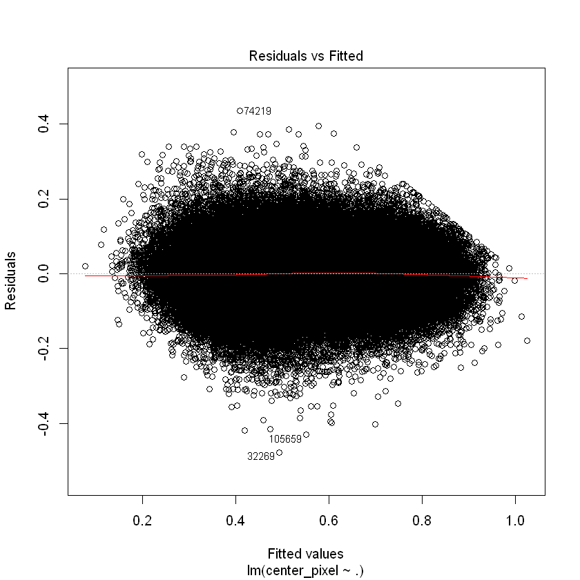

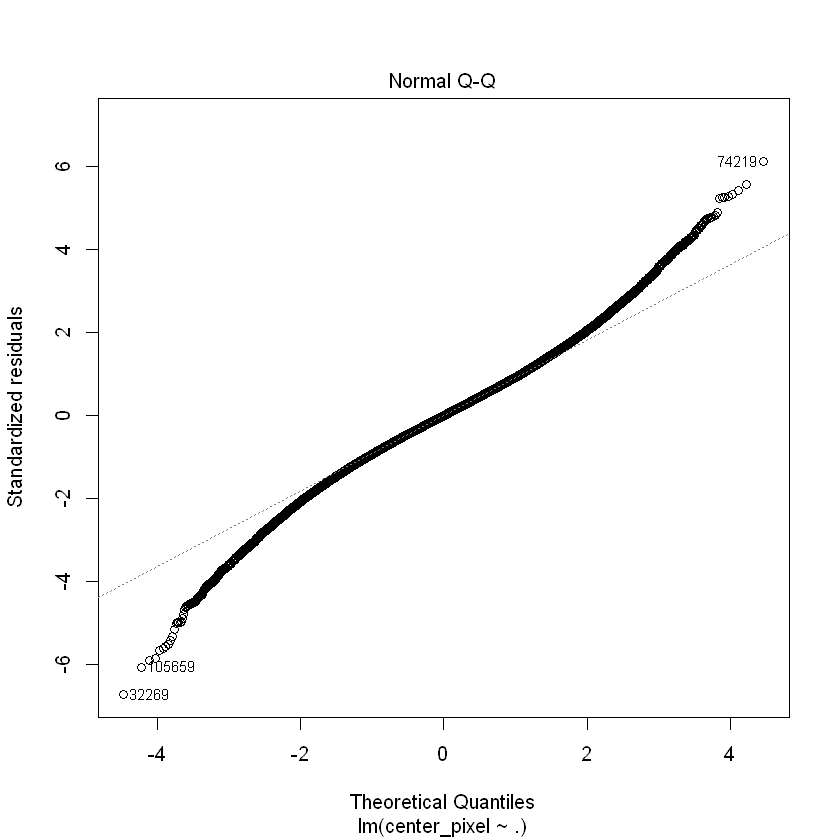

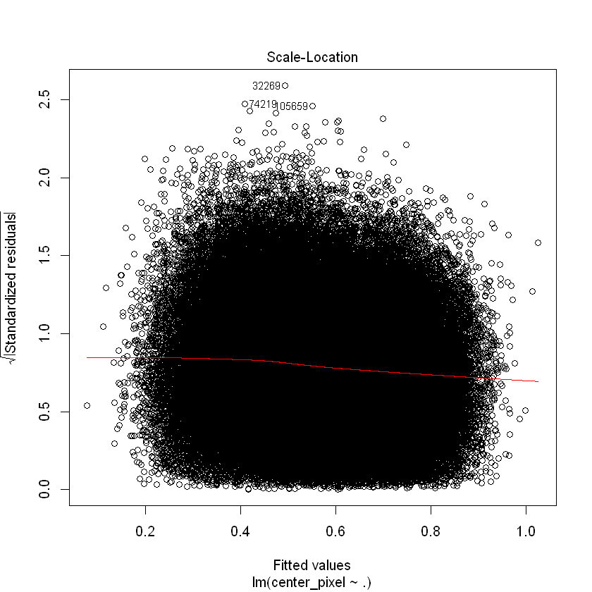

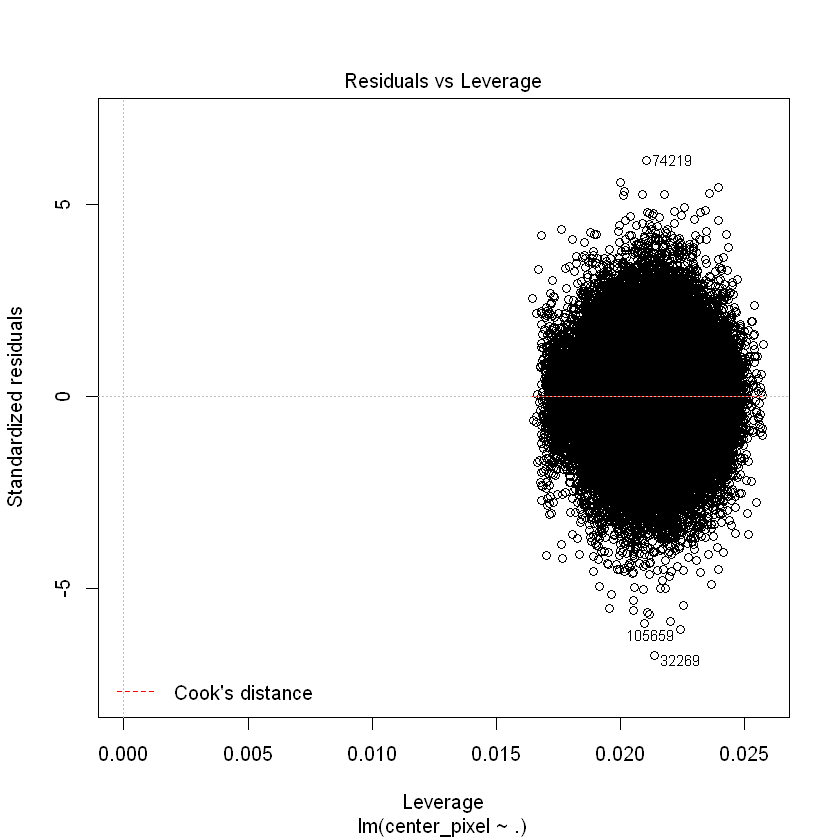

```r
regmodel<-lm(center_pixel~.,data=big_data)
summary(regmodel)
plot(regmodel)
```

The summary gives us a good clue about how well the regression has performed. The R squared is fair enough(as it is close to 1), however it cannot be fully trusted as there are many predictors in this model.

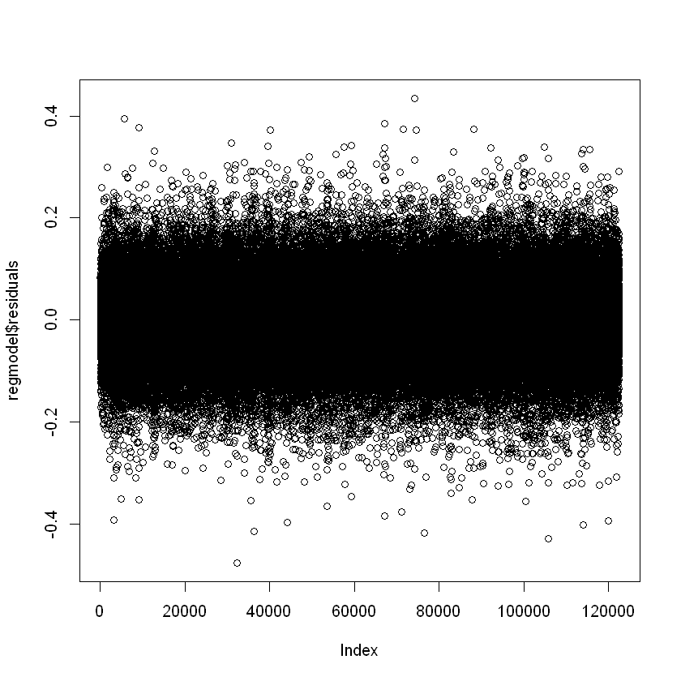

```r
plot(regmodel$residuals)
```

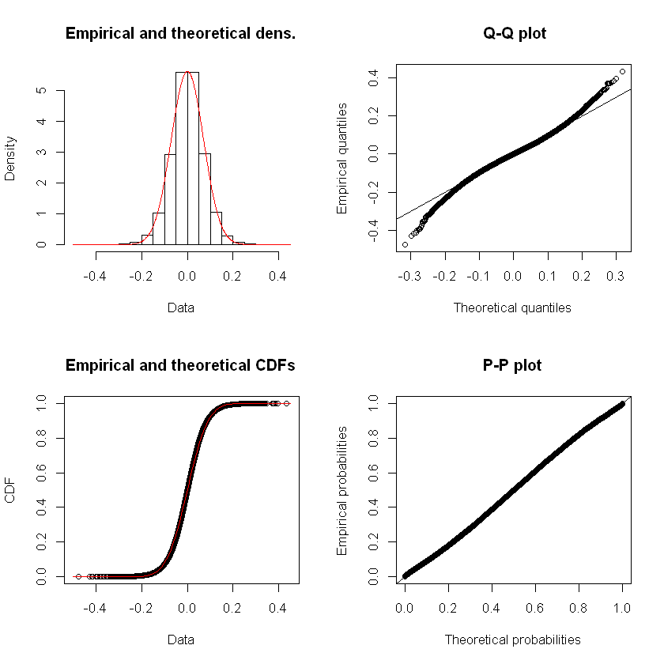

```r
library("fitdistrplus")
fit_res <- fitdist (regmodel$residuals, distr = "norm")
plot(fit_res)
```

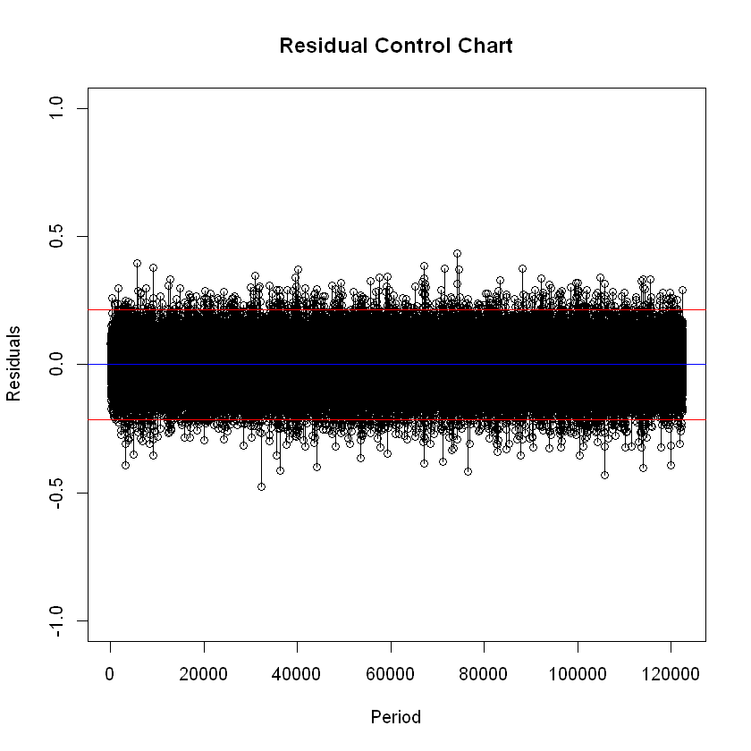

```r
plot(regmodel$residuals, ylim = c(-1,1), main = "Residual Control Chart", xlab = "Period", ylab = "Residuals")
lines(regmodel$residuals)
x_bar <- mean(regmodel$residuals)
st_dev <- sd(regmodel$residuals)
CL = x_bar
UCL = x_bar + 3*st_dev
LCL = x_bar - 3*st_dev
abline(LCL,0,col = "red")
abline(CL,0,col = "blue")
abline(UCL,0,col = "red")
```

As can be seen on the Residual Control Chart, there are points that are out of the confidence interval. This confirms that there will be a substantial number of central pixels that will be colored in black in the following steps.

At this point, we aim to build a mathematical algorithm to find the corresponding locations of central pixels from the residuals column of the regression model. The residual column has 122500 rows, each of this row holds a single cell representing the residual for a specific location in the original image (img_c). The intention of the below algorithm is to find the locations of these specific locations.

After using the algorithm, we located the locations whose predicted residuals are out-of-control. We colored them black while detecting them.

```r
for(i in 1:122500){
  if(regmodel$residuals[i]>UCL){
    if((i%%350)==0){
      img_c[((i/350)+25),((i-1)%%350)+26]=0
    }
    else{
      img_c[((i-(i%%350))/350)+26,((i-1)%%350)+26]=0
    }
  }
  else if(regmodel$residuals[i]<LCL){
    if((i%%350)==0){
      img_c[((i/350)+25),((i-1)%%350)+26]=0
    }
    else{
      img_c[((i-(i%%350))/350)+26,((i-1)%%350)+26]=0
    }
  }
}
```

Finally, we plotted the final image with replaced pixel values.

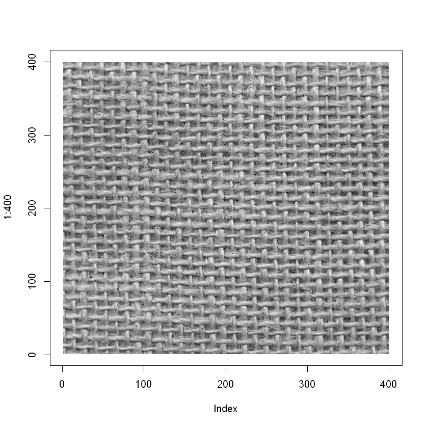

```r
plot(1:400, type='n')
rasterImage(img_c, 1,1,400,400)
```

The existence of autocorrelations of can also be understood intuitively. Since there are recurring patterns on the texture,the pixel values may depend on previous pixel values. One can also see the acf and pacf plots on R to see that there are lags in the data. In order to deal with the autocorrelation in the data, several approaches can be taken. The first is to use finite differencing the decrease the correlations. If more than one lag is needed, this procedure can be repeated till Acf and PAcf functions express normality.

Also, step-wise regression can be used to eliminate the predictors having the same effect on the output. This could be done by comparing ANOVA tables and F-values of each model, but would require many computations. If there is a special function for step-wise regression on R, that could be used as well.